# Problem Set 3

Author

Janet Wang

Git repository

https://github.com/janetjw/STATS506/blob/main/ProblemSets/JW_PS2.qmd

https://github.com/janetjw/STATS506/blob/main/ProblemSets/JW_PS2.html

## Problem 1

I referenced these stata manuals for importing SAS data and merging in stata: https://www.stata.com/manuals13/dimportsasxport.pdf https://www.stata.com/manuals/dmerge.pdf

### a

```stata
. clear

. cd "/Users/janetjw/Dropbox (University of Michigan)/STATS506/ProblemSets/"
/Users/janetjw/Dropbox (University of Michigan)/STATS506/ProblemSets

. import sasxport5 "VIX_D.XPT"

. tempfile vix_d

. save `vix_d'
file /var/folders/12/3jnlvfv534g58v853dkx2n380000gp/T//S_28265.000001 saved as .dta format

. import sasxport5 "DEMO_D.XPT"

. merge 1:1 _n using `vix_d', keep (match) nogenerate

    Result                      Number of obs
    -----------------------------------------
    Not matched                             0
    Matched                             6,980
    -----------------------------------------

. count
  6,980
```

### b

I used this manual to generate the crosstabulation https://www.stata.com/manuals/rtabulateoneway.pdf

```stata
. gen agecat = .
(6,980 missing values generated)

. replace agecat = 0 if ridageyr <= 9
(1,826 real changes made)

. replace agecat = 1 if ridageyr>= 10 & ridageyr <= 19
(1,831 real changes made)

. replace agecat = 2 if ridageyr>= 20 & ridageyr <= 29
(730 real changes made)

. replace agecat = 3 if ridageyr>= 30 & ridageyr <= 39
(562 real changes made)

. replace agecat = 4 if ridageyr>= 40 & ridageyr <= 49
(551 real changes made)

. replace agecat = 5 if ridageyr>= 50 & ridageyr <= 59
(429 real changes made)

. replace agecat = 6 if ridageyr>= 60 & ridageyr <= 69
(459 real changes made)

. replace agecat = 7 if ridageyr>= 70 & ridageyr <= 79
(325 real changes made)

. replace agecat = 8 if ridageyr>= 80
(267 real changes made)

.
. label define agecatl 0 "0-9" 1 "10-19" 2 "20-29" 3 "30-39" 4 "40-49" 5 "50-59" 6 "60-69" 7 "
> 70-79" 8 "80+"

. label values agecat agecatl
. label define viq220l 1 "Yes" 2 "No" 9 "Don't know"

. label values viq220 viq220l
. tab agecat viq220 , missing r

+----------------+
| Key            |
|----------------|
|   frequency    |
| row percentage |
+----------------+

           |  Glasses/contact lenses worn for distance
    agecat |       Yes         No  Don't kno          . |     Total
-----------+--------------------------------------------+----------
       0-9 |       691      1,032          0        103 |     1,826
           |     37.84      56.52       0.00       5.64 |    100.00
-----------+--------------------------------------------+----------
     10-19 |       724        977          1        129 |     1,831
           |     39.54      53.36       0.05       7.05 |    100.00
-----------+--------------------------------------------+----------
     20-29 |       310        379          0         41 |       730
           |     42.47      51.92       0.00       5.62 |    100.00
-----------+--------------------------------------------+----------
     30-39 |       234        286          0         42 |       562
           |     41.64      50.89       0.00       7.47 |    100.00
-----------+--------------------------------------------+----------
     40-49 |       210        307          0         34 |       551
           |     38.11      55.72       0.00       6.17 |    100.00
-----------+--------------------------------------------+----------
     50-59 |       171        233          0         25 |       429
           |     39.86      54.31       0.00       5.83 |    100.00
-----------+--------------------------------------------+----------
     60-69 |       176        260          0         23 |       459
           |     38.34      56.64       0.00       5.01 |    100.00
-----------+--------------------------------------------+----------
     70-79 |       139        164          1         21 |       325
           |     42.77      50.46       0.31       6.46 |    100.00
-----------+--------------------------------------------+----------
       80+ |       110        142          0         15 |       267
           |     41.20      53.18       0.00       5.62 |    100.00
-----------+--------------------------------------------+----------
     Total |     2,765      3,780          2        433 |     6,980
           |     39.61      54.15       0.03       6.20 |    100.00
```

### c

For this part, I deleted the two observations that answered “don’t know” to the vision question (dependent variable). Missings are dropped automatically when the logistic regression is conducted.

I used the stata manual on logistic regression and calculating information criteria: https://www.stata.com/manuals/rlogit.pdf https://www.stata.com/manuals/ricnote.pdf

```stata
. drop if viq220 == 9
(2 observations deleted)

. replace viq220 = 0 if viq220 == 2
(3,780 real changes made)

. logit viq220 ridageyr, or

Iteration 0:  Log likelihood = -4457.6265
Iteration 1:  Log likelihood = -4456.8023
Iteration 2:  Log likelihood = -4456.8023

Logistic regression                                     Number of obs =  6,545
                                                        LR chi2(1)    =   1.65
                                                        Prob > chi2   = 0.1992
Log likelihood = -4456.8023                             Pseudo R2     = 0.0002

------------------------------------------------------------------------------
      viq220 | Odds ratio   Std. err.      z    P>|z|     [95% conf. interval]
-------------+----------------------------------------------------------------
    ridageyr |   1.001334   .0010394     1.28   0.199     .9992992    1.003374
       _cons |   .7047893   .0269956    -9.13   0.000     .6538163    .7597363
------------------------------------------------------------------------------
Note: _cons estimates baseline odds.

. estat ic

Akaike's information criterion and Bayesian information criterion

-----------------------------------------------------------------------------
       Model |          N   ll(null)  ll(model)      df        AIC        BIC
-------------+---------------------------------------------------------------
           . |      6,545  -4457.627  -4456.802       2   8917.605   8931.177
-----------------------------------------------------------------------------
Note: BIC uses N = number of observations. See [R] IC note.

.
. logit viq220 ridageyr ridreth1 riagendr, or

Iteration 0:  Log likelihood = -4457.6265
Iteration 1:  Log likelihood = -4455.3966
Iteration 2:  Log likelihood = -4455.3966

Logistic regression                                     Number of obs =  6,545
                                                        LR chi2(3)    =   4.46
                                                        Prob > chi2   = 0.2159
Log likelihood = -4455.3966                             Pseudo R2     = 0.0005

------------------------------------------------------------------------------
      viq220 | Odds ratio   Std. err.      z    P>|z|     [95% conf. interval]
-------------+----------------------------------------------------------------
    ridageyr |   1.001532    .001047     1.46   0.143     .9994824    1.003587
    ridreth1 |   .9676925   .0196083    -1.62   0.105      .930014    1.006898
    riagendr |   1.021248   .0511375     0.42   0.675     .9257816    1.126559
       _cons |   .7436445   .0742972    -2.96   0.003     .6113955    .9044999
------------------------------------------------------------------------------
Note: _cons estimates baseline odds.

. estat ic

Akaike's information criterion and Bayesian information criterion

-----------------------------------------------------------------------------
       Model |          N   ll(null)  ll(model)      df        AIC        BIC
-------------+---------------------------------------------------------------
           . |      6,545  -4457.627  -4455.397       4   8918.793   8945.939
-----------------------------------------------------------------------------
Note: BIC uses N = number of observations. See [R] IC note.

.
. logit viq220 ridageyr ridreth1 riagendr indfmpir, or

Iteration 0:  Log likelihood =  -4218.266
Iteration 1:  Log likelihood = -4215.7305
Iteration 2:  Log likelihood = -4215.7305

Logistic regression                                     Number of obs =  6,195
                                                        LR chi2(4)    =   5.07
                                                        Prob > chi2   = 0.2801
Log likelihood = -4215.7305                             Pseudo R2     = 0.0006

------------------------------------------------------------------------------
      viq220 | Odds ratio   Std. err.      z    P>|z|     [95% conf. interval]
-------------+----------------------------------------------------------------
    ridageyr |   1.001663   .0010969     1.52   0.129      .999516    1.003816
    ridreth1 |   .9706044   .0205664    -1.41   0.159     .9311206    1.011763
    riagendr |   1.002546   .0516208     0.05   0.961     .9063093    1.109003
    indfmpir |   .9827507   .0164527    -1.04   0.299     .9510272    1.015532
       _cons |   .7865116   .0839908    -2.25   0.025     .6379787    .9696257
------------------------------------------------------------------------------
Note: _cons estimates baseline odds.

. estat ic

Akaike's information criterion and Bayesian information criterion

-----------------------------------------------------------------------------
       Model |          N   ll(null)  ll(model)      df        AIC        BIC
-------------+---------------------------------------------------------------
           . |      6,195  -4218.266   -4215.73       5   8441.461   8475.118
-----------------------------------------------------------------------------
Note: BIC uses N = number of observations. See [R] IC note.
```

### d

The odds of men and women being wears of glasses/contact lenses for distance vision does not differ, as the p-value for the gender coefficient in the model is greater than 0.05. This comes from the model output of part c. (Odds ratio is 1.002546 and the p-value is 0.961.)

To test if the proportions of glasses/contacts wearers for distance, I conduct a z test. The null hypothesis is that the difference between population proportion for male and female glasses/contact wearers for distance is zero, whereas the alternative hypothesis is that the difference between population proportion for male and female glasses/contact wearers for distance is greater than zero.

I use this manual to figure out how to conduct a z-test: https://www.stata.com/manuals/rztest.pdf

```stata
. ztest viq220, by(riagendr)

Two-sample z test
------------------------------------------------------------------------------
   Group |     Obs        Mean    Std. err.   Std. dev.   [95% conf. interval]
---------+--------------------------------------------------------------------
       1 |   3,223    .4197952    .0176145           1    .3852715     .454319
       2 |   3,322    .4250452      .01735           1    .3910397    .4590506
---------+--------------------------------------------------------------------
    diff |           -.0052499    .0247243               -.0537088    .0432089
------------------------------------------------------------------------------
    diff = mean(1) - mean(2)                                      z =  -0.2123
H0: diff = 0

    Ha: diff < 0                 Ha: diff != 0                 Ha: diff > 0
 Pr(Z < z) = 0.4159         Pr(|Z| > |z|) = 0.8318          Pr(Z > z) = 0.5841
```

# Problem 2

### a

```r
#loading in dataset and familiarizing with the names of the datasets
sakila <- dbConnect(RSQLite::SQLite(), "sakila_master.db")
dbListTables(sakila)
```

```
 [1] "actor"                  "address"                "category"
 [4] "city"                   "country"                "customer"
 [7] "customer_list"          "film"                   "film_actor"
[10] "film_category"          "film_list"              "film_text"
[13] "inventory"              "language"               "payment"
[16] "rental"                 "sales_by_film_category" "sales_by_store"
[19] "staff"                  "staff_list"             "store"
```

```r
dbListFields(sakila, "language")
```

```
[1] "language_id" "name"        "last_update"
```

```r
dbListFields(sakila, "film")
```

```
 [1] "film_id"              "title"                "description"
 [4] "release_year"         "language_id"          "original_language_id"
 [7] "rental_duration"      "rental_rate"          "length"
[10] "replacement_cost"     "rating"               "special_features"
[13] "last_update"
```

```r
#single query to get the language names from the most frequent language in film after English -- merging the film and language datasets with film id, keeping those in film, and counting the number of appearances of each language in film and presenting by highest order

dbGetQuery(sakila, "
SELECT name, COUNT(l.language_id) AS count
  FROM language AS l
       RIGHT JOIN
       (SELECT f.language_id
          FROM film AS f
       ) AS ff ON ff.language_id = l.language_id
 GROUP BY ff.language_id
 ORDER by count")
```

```
     name count
1 English  1000
```

There are only English movies! Thus, there is no second-most frequent language in this dataset after English.

### b

First way, using R

I used this stack overflow to get a count() table in descending order: https://stackoverflow.com/questions/35830859/sorting-output-of-tally-count-dplyr

```r
film_category <- dbGetQuery(sakila, "
SELECT *
  FROM film_category
")

category <- dbGetQuery(sakila, "
SELECT *
  FROM category
")

film_category <- merge(film_category, category, by = "category_id", all.x = T)

film_category %>%
  group_by(name) %>%
    count() %>%
    arrange(desc(n))
```

```
# A tibble: 16 × 2
# Groups:   name [16]
   name            n
   <chr>       <int>
 1 Sports         74
 2 Foreign        73
 3 Family         69
 4 Documentary    68
 5 Animation      66
 6 Action         64
 7 New            63
 8 Drama          62
 9 Games          61
10 Sci-Fi         61
11 Children       60
12 Comedy         58
13 Classics       57
14 Travel         57
15 Horror         56
16 Music          51
```

The most popular genre is sports (the genre comprises 74 of 1000 films).

Second way, using SQL

```r
#Joining appearances of each category and film category and then counting from top down

dbGetQuery(sakila, "
SELECT c.category_id, c.name, COUNT(f.category_id) AS appear
  FROM film_category AS f
       INNER JOIN category AS c ON f.category_id = c.category_id
 GROUP BY c.name
 ORDER BY -appear
 LIMIT 4
")
```

```
  category_id        name appear
1          15      Sports     74
2           9     Foreign     73
3           8      Family     69
4           6 Documentary     68
```

We see that sports genre appears the most, 74 times.

### c

First way, using R

```r
customer <- dbGetQuery(sakila, "
SELECT *
  FROM customer
")
city <- dbGetQuery(sakila, "
SELECT *
  FROM city
")
address <- dbGetQuery(sakila, "
SELECT *
  FROM address
")
country <- dbGetQuery(sakila, "
SELECT *
  FROM country
")

#merging datasets with common id, similar to how I did it for part b above

customer_merged <- merge(customer, address[c("address_id", "city_id")], by = "address_id", all.x = T)
customer_merged <- merge(customer_merged, city[c("country_id", "city_id")], by = "city_id", all.x = T)
customer_merged <- merge(customer_merged, country[c("country_id", "country")], by = "country_id")

#creating summary table at country table and filtering out which country has 9 customers
country_table <- customer_merged %>%
  group_by(country) %>%
  summarize(customers = n())

country_table %>%
  filter(customers == 9)
```

```
# A tibble: 1 × 2
  country        customers
  <chr>              <int>
1 United Kingdom         9
```

We see that the United Kingdom has exactly 9 customers.

Second way, using SQL

```r
#doing a simliar thing but in SQL, continuously merging via common id as inner joins -- address_id, city_id, country_id, to country and then limiting output to countries with 9 customers

dbGetQuery(sakila, "
  SELECT co.country, co.country_id, count(co.country) AS customers
   FROM customer as cu
    INNER JOIN address as ad ON ad.address_id = cu.address_id
    INNER JOIN city as ci ON ci.city_id = ad.city_id
    INNER JOIN country as co ON co.country_id = ci.country_id
    GROUP BY co.country
    HAVING customers == 9
  ")
```

```
         country country_id customers
1 United Kingdom        102         9
```

Once againm, we see that the United Kingdom has exactly 9 customers.

# Problem 3

### a

```r
us <- read.csv("us-500.csv")

sum(grepl(".net$", us$email))/nrow(us)
```

```
[1] 0.14
```

0.14 of the email addresses in this dataset are hosted at a domain with TLD “.net”.

### b

I used this stack overflow post to figure out how to write alphanumeric characters: https://stackoverflow.com/questions/8959243/remove-non-alphanumeric-symbols-from-a-string

```r
#us$email[which(grepl("^([[:alnum:]])+[\\@]", us$email) )]

#This expression excludes those who only have alphanumeric charactes prior to the @ before the domain main. I allow people to have '.' in their emails if they come before the domain.

length(us$email[-which(grepl("^([[:alnum:]])+[\\@]", us$email) )] )/ length(us$email)
```

```
[1] 0.506
```

0.506 of the emails have at least one nonalphanumeric character in them.

### c

```r
#creating tables with area codes for first and second phone numbers
areacodes1 <- as.data.frame(substr(us$phone1, 1,3)); colnames(areacodes1) <- "code"
areacodes2 <- as.data.frame(substr(us$phone2, 1,3)); colnames(areacodes2) <- "code"

#row bind to create one big table of area codes
areacodes <- rbind(areacodes1, areacodes2); areacodes$code <- as.factor(areacodes$code)

#creating a summary table -- getting the six most freqeuent area codes by first calculating frequency of appearances
head(areacodes %>%
group_by(code) %>%
  summarise(freq = n()) %>%
      arrange(desc(freq))
  )
```

```
# A tibble: 6 × 2
  code   freq
  <fct> <int>
1 973      36
2 212      28
3 215      28
4 410      28
5 201      24
6 305      18
```

973 is the most popular area code, it appears 36 times across columns phone1 and phone2.

### d

This stack overflow post helped me with extracting the second elements from the list: https://stackoverflow.com/questions/22430365/extract-second-element-from-every-item-in-a-list

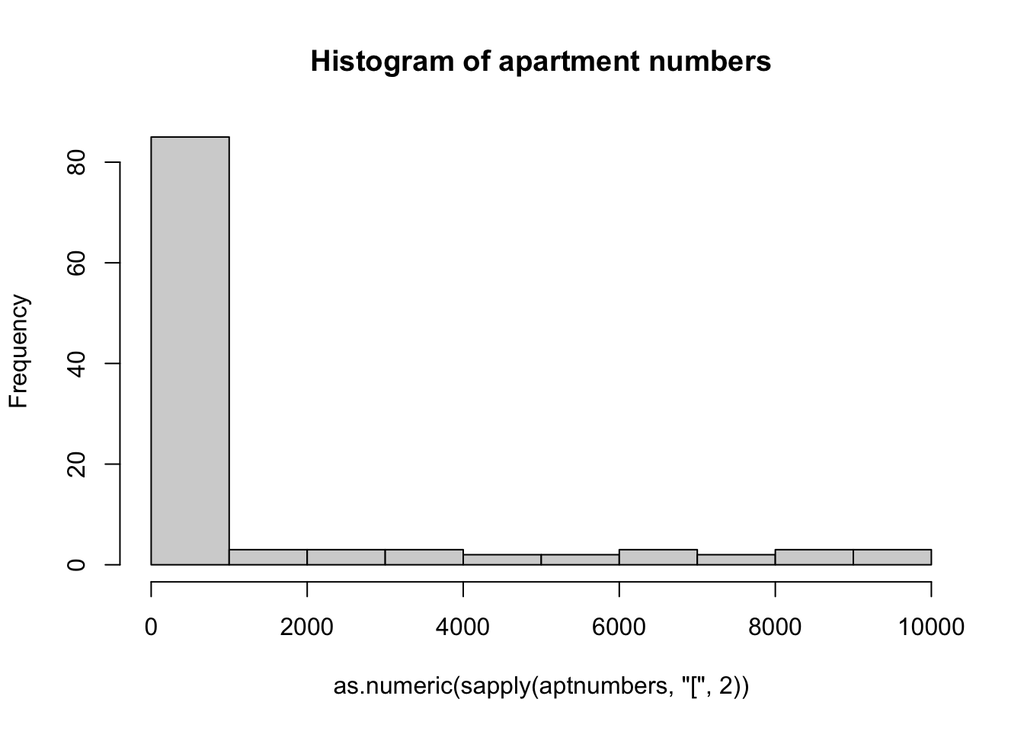

```r
#collecting the addresses and splitting them into the before and after # sign
aptnumbers <- strsplit(us$address[grep("#+[0-9]+$", us$address)], " #")

#extracting the apartment numbers and creating the histogram
hist(as.numeric(sapply(aptnumbers, "[", 2)), main ="Histogram of apartment numbers", x=)
```

### e

```r
#creating vector of apartment numbers, substringing the first digit, and making it into a dataframe
aptnumber.vec <- as.numeric(sapply(aptnumbers, "[", 2))
leading <- as.data.frame(substr(aptnumber.vec, 1, 1)); colnames(leading) <- "leading"

#creating summary table -- for every leading digit, getting the frequency, proportion of times it shows up, and what Benford's law would suggest about the distribution
leading %>%
  group_by(leading) %>%
  summarize(count=n()) %>%
  mutate(freq = count/sum(count),
         probability = log10(1+1/as.numeric(leading)))
```

```
# A tibble: 9 × 4
  leading count   freq probability
  <chr>   <int>  <dbl>       <dbl>
1 1          11 0.101       0.301
2 2          11 0.101       0.176
3 3          12 0.110       0.125
4 4          11 0.101       0.0969
5 5          14 0.128       0.0792
6 6          10 0.0917      0.0669
7 7          12 0.110       0.0580
8 8          11 0.101       0.0512
9 9          17 0.156       0.0458
```

Based on this mismatch between the observed frequencies of the digits occurence and the calculated probabilities according to Benford’s law, this seems to not resemble real data. For instance, 1 and 2 appear less frequently than Benford’s law states and digits 5 to 9 appear much more than the law would suggest.

### e

This stack overflow post helped me find out the way to write a space with regular expressions: https://stackoverflow.com/questions/25477920/get-characters-before-first-space

```r
#getting the street number
streetnumbers <- gsub(" .*", "", us$address)
#getting the last digit
ending <- as.data.frame(substr(streetnumbers, nchar(streetnumbers), nchar(streetnumbers))); colnames(ending) <- "ending"

#removing last digits that end with zero
ending <- as.data.frame(ending[-which(ending$ending == "0"),]); colnames(ending) <- "ending"

#creating summary table -- for every leading digit, getting the frequency, proportion of times it shows up, and what Benford's law would suggest about the distribution
ending %>%
  group_by(ending) %>%
  summarize(count=n()) %>%
  mutate(freq = count/sum(count),
         probability = log10(1+1/as.numeric(ending)))
```

```
# A tibble: 9 × 4
  ending count   freq probability
  <chr>  <int>  <dbl>       <dbl>
1 1         41 0.0889      0.301
2 2         54 0.117       0.176
3 3         51 0.111       0.125
4 4         53 0.115       0.0969
5 5         52 0.113       0.0792
6 6         43 0.0933      0.0669
7 7         56 0.121       0.0580
8 8         45 0.0976      0.0512
9 9         66 0.143       0.0458
```

We see that probabilities don’t really reflect the frequencies at which these digits occur, While 3, 4 aren’t too far off, other digits occur much more or less frequently than Benford’s law would suggest.